# Validation Methods in Latent Class Analysis

2026-04-10

```r
# Core packages for LCA in R
# install.packages(c("poLCA", "dplyr", "ggplot2", "tidyr", "caret"))
library(poLCA)
library(dplyr)
library(ggplot2)
library(tidyr)
```

# 1 Overview

Validating an LCA model is a critical final step to ensure that the identified class solutions are theoretically meaningful, robust, and generalizable beyond the sample. Validation methods fall into three main categories:

| Category | Core Question |
| --- | --- |
| **Construct validity** | Do the classes relate to external variables in theoretically expected ways? |
| **External validity** | Do the same classes replicate in other samples or populations? |
| **Statistical cross-validation** | Do the model’s parameter estimates generalize to held-out data? |

These three forms of validity are complementary. A model can possess high construct validity (the classes are theoretically coherent within one sample) while simultaneously failing external validity (they do not replicate elsewhere).

# 2 Construct Validity

## 2.1 Conceptual Basis

Construct validity in LCA evaluates whether the empirically derived latent classes represent genuine, theoretically meaningful subgroups rather than mathematical artifacts of the clustering algorithm. It is established by demonstrating that class membership systematically correlates with **unmodeled external variables**—covariates (predictors) or distal outcomes (consequences)—in ways that align with established theory and prior research.

Construct validity cannot be established in a vacuum. For a typology to be deemed valid, its association with external variables must be consistent with prior theoretical frameworks. For example, if a researcher identifies a class characterized by exclusionary attitudes, construct validity is supported if membership in that class correlates with expected demographic variables (e.g., specific education levels, political affiliation) as theory predicts.

## 2.2 Covariates as an Interpretational Tool

External variables used to validate and predict class membership are called **covariates**. Introducing covariates into an LCA answers substantive questions such as:

- Does the composition of the classes differ by sociodemographic characteristics?
- Does class membership predict a theoretically relevant distal outcome?

Common categories of covariates include:

**Demographic and socioeconomic:** gender, age, maternal education level, income, ethnicity, primary language

**Ideological and political:** political affiliation, religious identity, specific policy opinions, voting behavior

**Behavioral:** substance use markers (cigarette use, alcohol consumption), academic indicators (school grades, absenteeism)

**Distal outcomes:** clinical diagnoses (ADHD, behavior problems), macro-political outcomes (anti-immigrant sentiment, vote choice)

**Experimental:** random assignment to treatment conditions

## 2.3 Statistical Implementation

Testing the association between latent classes and external variables relies on **logistic regression frameworks**.

| Approach | When to use |
| --- | --- |
| Multinomial logistic regression | Predicting membership across all classes simultaneously; one class set as reference |
| Binomial logistic regression | Comparing one target class against all others combined |

Regression coefficients ($\beta$) are exponentiated ($e^\beta$) to yield **odds ratios (ORs)**:

- OR = 1.0: the covariate has no effect on class membership
- OR > 1.0: the covariate increases the odds of belonging to the target class
- OR < 1.0: the covariate decreases those odds

## 2.4 Evolution of Methodological Best Practices

### 2.4.1 The Flawed Classify-Analyze Approach

Historically, researchers assigned individuals to the single class with the highest posterior probability and then ran standard statistical tests (ANOVA, logistic regression) against external variables. This **classify-analyze** approach treats probabilistic assignments as 100% certain, completely ignoring classification uncertainty. The result is biased inference.

### 2.4.2 The Flawed One-Step Approach

A later approach included covariates directly in the same model used to identify the latent classes. The problem: external variables can inadvertently alter the measurement model, changing the fundamental definition of the latent classes.

### 2.4.3 The Modern Three-Step Approach

Current best practice is the **three-step approach** (Vermunt, 2010; Bolck, Croon & Hagenaars, 2004):

**Step 1 — Identify the measurement model.** Estimate the LCA using only the primary indicator variables. Evaluate model fit using BIC, AIC, and theoretical interpretability. Select the optimal class solution.

**Step 2 — Fix the measurement parameters.** Lock in the item-response probabilities and class prevalences from the best-fitting model. These parameters do not change when external variables are introduced.

**Step 3 — Add covariates as auxiliary variables.** Introduce covariates and distal outcomes. Because the measurement parameters are fixed, the class definitions cannot be distorted. Classification uncertainty is properly incorporated into the final estimation. Pairwise Wald tests assess how specific latent profiles are associated with outcomes.

```r
# ─── Simulated example: Three-step approach with poLCA ───────────────────────

# Step 0: Simulate binary indicator data (4 items, 3 latent classes)
set.seed(42)
n <- 600

# Latent class memberships (class sizes: 40%, 35%, 25%)
true_class <- sample(1:3, n, replace = TRUE, prob = c(0.40, 0.35, 0.25))

# Item-response probabilities per class
probs <- list(
  # Class 1 (high probability of "1" on all items)
  c(0.85, 0.80, 0.78, 0.82),
  # Class 2 (moderate)
  c(0.50, 0.45, 0.55, 0.40),
  # Class 3 (low)
  c(0.15, 0.20, 0.12, 0.18)
)

# Generate observed responses
sim_data <- as.data.frame(do.call(cbind, lapply(1:4, function(j) {
  sapply(true_class, function(k) rbinom(1, 1, probs[[k]][j]) + 1L)
})))
names(sim_data) <- paste0("Y", 1:4)

# Add a covariate for construct validity testing (e.g., education level)
sim_data$education <- ifelse(
  true_class == 1, rnorm(n, mean = 16, sd = 2),
  ifelse(true_class == 2, rnorm(n, mean = 13, sd = 2), rnorm(n, mean = 10, sd = 2))
)

# ─── Step 1: Estimate measurement model (indicators only) ────────────────────
f <- cbind(Y1, Y2, Y3, Y4) ~ 1

lca_3class <- poLCA(f, data = sim_data, nclass = 3,
                    nrep = 10, maxiter = 1000, verbose = FALSE)

cat("BIC:", lca_3class$bic, "\n")
```

```
## BIC: 3181.594
```

```r
cat("AIC:", lca_3class$aic, "\n")
```

```
## AIC: 3120.037
```

```r
# ─── Step 2: Assign modal classes & extract posterior probabilities ───────────
# poLCA stores posterior probabilities in lca_3class$posterior
# Modal class assignment (for reference; not used directly in Step 3)
sim_data$modal_class <- lca_3class$predclass

# Step 3: Test association of modal class with the covariate
# (using multinomial logistic regression as a proxy for the full 3-step)
# For a proper bias-corrected 3-step, use MplusAutomation or the 'BCH' method.
# The approach below illustrates the logic.

library(nnet)
sim_data$modal_class_f <- factor(sim_data$modal_class)

model_covariate <- multinom(modal_class_f ~ education,
                             data = sim_data, trace = FALSE)
summary(model_covariate)
```

```
## Call:
## multinom(formula = modal_class_f ~ education, data = sim_data,
##     trace = FALSE)
##
## Coefficients:
##   (Intercept)  education
## 2    7.644266 -0.5802906
## 3    4.892438 -0.3143314
##
## Std. Errors:
##   (Intercept)  education
## 2   0.7208421 0.05206734
## 3   0.6294641 0.04205243
##
## Residual Deviance: 1105.022
## AIC: 1113.022
```

```r
# ─── Odds ratios from the multinomial model ───────────────────────────────────
coefs <- coef(model_covariate)
OR    <- exp(coefs)

cat("\nOdds Ratios (relative to Class 1 as reference):\n")
```

```
##
## Odds Ratios (relative to Class 1 as reference):
```

```r
print(round(OR, 3))
```

```
##   (Intercept) education
## 2    2088.636      0.56
## 3     133.278      0.73
```

```r
# OR > 1 on 'education' coefficient means higher education increases
# the odds of being in that class relative to the reference class.
```

# 3 External Validity (Replication)

## 3.1 Core Logic

External validity ensures that the identified latent classes are not artifacts of a single, idiosyncratic dataset. Researchers validate their classes by **conducting the exact same analysis in different samples** (different years, different countries, or a distinct subset of the original sample). When the same configurations emerge repeatedly, the typology is considered externally valid.

If a typology is externally valid, the same configurations of attitudes, behaviors, or traits should emerge across distinct datasets. In studies of political culture and nationalism, for example, a four-class typology of nationalist sentiments was successfully replicated across multiple survey years and in surveys from different countries.

## 3.2 Multiple-Group LCA and Measurement Invariance

Beyond running separate models on different datasets, researchers can formally test external validity using **Multiple-Group LCA**. A grouping variable (gender, cohort, country, etc.) is introduced, and two nested models are compared:

| Model | Description |
| --- | --- |
| **Model 1 (Unconstrained)** | Item-response probabilities freely estimated, allowed to vary across groups |
| **Model 2 (Constrained)** | Item-response probabilities forced to be equal across groups |

The gold standard is **measurement invariance**: individuals who belong to the same latent class but come from different populations have the exact same probability of providing any given observed response pattern.

## 3.3 The G² Difference Test

Because Model 2 is nested within Model 1, they are compared with the **likelihood-ratio difference test**:

$$G^2_{\text{diff}} = G^2_{\text{Model 2}}
- G^2_{\text{Model 1}}$$

This statistic follows a $\chi^2$ distribution. The degrees of freedom equal the difference in degrees of freedom between the two models ($df_2 - df_1$), which equals the difference in the number of free parameters.

**Interpretation:**

- **Non-significant $G^2_{\text{diff}}$**: Model 2 fits approximately as well as Model 1. The parameter restrictions are plausible. Measurement invariance holds. Direct group comparisons are valid (“apples-to-apples”).
- **Significant $G^2_{\text{diff}}$**: Forcing equal item-response probabilities significantly worsens fit. Measurement invariance fails. The latent variable has qualitatively different meanings across groups (“apples-to-oranges”).

Note: Because the $G^2$ difference test is sensitive to sample size, researchers should also visually inspect the magnitude of the differences between item-response probabilities. Minor statistical significance driven by a large $n$ may not constitute a conceptually important difference. In such cases, researchers may impose measurement invariance anyway, accepting a slight misspecification in favor of parsimony.

**Critical exception:** The $G^2$ difference test is mathematically invalid for comparing models with *different numbers of latent classes* (e.g., 3-class vs. 4-class). For that comparison, use AIC, BIC, or the parametric bootstrap likelihood-ratio test.

## 3.4 Implications of Invariance Results

| Outcome | Interpretation | Consequence |
| --- | --- | --- |
| Invariance holds | Classes have identical meaning across groups | Quantitative differences only; prevalences can be compared directly |
| Invariance fails | Latent structure differs across groups | Qualitative differences; direct prevalence comparisons are invalid |
| Partial invariance | Some item-response probabilities differ | Constrain equal parameters; free differing ones |

```r
# ─── Multiple-Group LCA: Testing measurement invariance in poLCA ─────────────

# Add a binary group variable (e.g., two cohorts)
sim_data$group <- ifelse(seq_len(n) <= n / 2, 1, 2)

# Split into groups
data_g1 <- sim_data[sim_data$group == 1, ]
data_g2 <- sim_data[sim_data$group == 2, ]

# Model 1 (Unconstrained): Separate LCA for each group
lca_g1 <- poLCA(f, data = data_g1, nclass = 3,
                nrep = 10, maxiter = 1000, verbose = FALSE)
lca_g2 <- poLCA(f, data = data_g2, nclass = 3,
                nrep = 10, maxiter = 1000, verbose = FALSE)

G2_unconstrained <- lca_g1$Gsq + lca_g2$Gsq
df_unconstrained  <- lca_g1$df  + lca_g2$df

cat("Model 1 (Unconstrained):\n")
```

```
## Model 1 (Unconstrained):
```

```r
cat("  G2 =", round(G2_unconstrained, 3), "| df =", df_unconstrained, "\n\n")
```

```
##   G2 = 2.984 | df =
```

```r
# Model 2 (Constrained): Single LCA on full data (approximation of invariance)
# A proper constrained model requires Mplus or manual parameter constraints.
# poLCA does not natively support constrained multi-group LCA;
# the code below demonstrates the G2 difference logic.

lca_pooled <- poLCA(f, data = sim_data, nclass = 3,
                    nrep = 10, maxiter = 1000, verbose = FALSE)

G2_constrained <- lca_pooled$Gsq
df_constrained  <- lca_pooled$df

cat("Model 2 (Constrained / pooled approximation):\n")
```

```
## Model 2 (Constrained / pooled approximation):
```

```r
cat("  G2 =", round(G2_constrained, 3), "| df =", df_constrained, "\n\n")
```

```
##   G2 = 1.078 | df =
```

```r
# G2 difference test
G2_diff <- G2_constrained - G2_unconstrained
df_diff  <- df_constrained  - df_unconstrained
p_value  <- pchisq(G2_diff, df = df_diff, lower.tail = FALSE)

cat("G2 Difference Test:\n")
```

```
## G2 Difference Test:
```

```r
cat("  G2_diff =", round(G2_diff, 3), "\n")
```

```
##   G2_diff = -1.906
```

```r
cat("  df_diff =", df_diff, "\n")
```

```
##   df_diff =
```

```r
cat("  p-value =", round(p_value, 4), "\n")
```

```
##   p-value =
```

```r
cat("  Interpretation:",
    ifelse(p_value > 0.05,
           "Non-significant — measurement invariance supported",
           "Significant — measurement invariance fails"), "\n")
```

```
##   Interpretation:
```

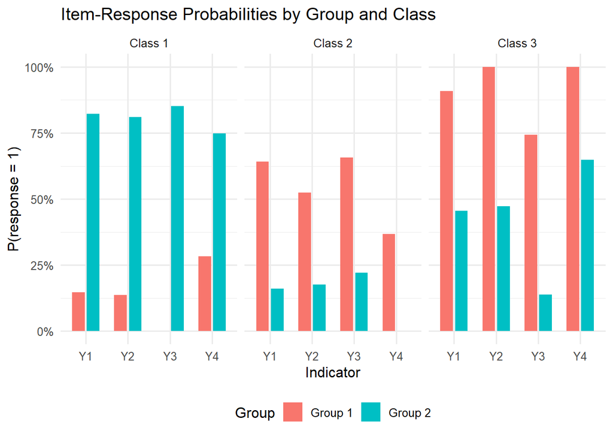

```r
# ─── Visual comparison of item-response probabilities across groups ───────────
# Useful for judging conceptual importance when G2 test is borderline

extract_probs <- function(model, group_label) {
  probs_list <- model$probs
  result <- lapply(seq_along(probs_list), function(i) {
    p <- probs_list[[i]]
    data.frame(
      item   = names(probs_list)[i],
      class  = paste0("Class ", seq_len(nrow(p))),
      prob   = p[, 2],     # probability of response category "2" (i.e., 1)
      group  = group_label
    )
  })
  do.call(rbind, result)
}

probs_g1 <- extract_probs(lca_g1, "Group 1")
probs_g2 <- extract_probs(lca_g2, "Group 2")
probs_all <- rbind(probs_g1, probs_g2)

ggplot(probs_all, aes(x = item, y = prob, fill = group)) +
  geom_bar(stat = "identity", position = position_dodge(width = 0.7),
           width = 0.6) +
  facet_wrap(~ class) +
  scale_y_continuous(limits = c(0, 1), labels = scales::percent) +
  labs(title = "Item-Response Probabilities by Group and Class",
       x = "Indicator", y = "P(response = 1)", fill = "Group") +
  theme_minimal(base_size = 12) +
  theme(legend.position = "bottom")
```

# 4 Statistical Cross-Validation

## 4.1 Purpose

Statistical cross-validation determines whether an estimated LCA model can generalize to other data sets, or if its parameter estimates are overly driven by the idiosyncrasies of the specific sample (i.e., **overfitting**). Cross-validation serves as a model selection tool during the class enumeration phase.

## 4.2 Methods

### 4.2.1 Simple Cross-Validation

1. Randomly partition the data into a **training set** and a **validation set**.
2. Estimate the LCA (EM algorithm) on the training set. Parameters: latent class prevalences $\gamma$ and item-response probabilities $\rho$.
3. Fix those parameters and apply them to the validation set.
4. Calculate a goodness-of-fit statistic (e.g., $G^2$) on the validation set.
5. If the model fits the validation set acceptably, it validates well.

### 4.2.2 Double (Twofold) Cross-Validation

1. Randomly split the data into two equal halves: **Data Set A** and **Data Set B**.
2. Fit the model to A; assess fit on B.
3. Fit the model to B; assess fit on A.
4. Select the model that performs best across both validation sets.

### 4.2.3 k-Fold Cross-Validation

1. Randomly partition the data into $k$ equal subsamples.
2. Repeat $k$ times: hold out one subsample as the validation set; train on the remaining $k-1$ subsamples.
3. Evaluate the $k$ resulting fit indices.
4. Select the model that performs best across all $k$ validation sets.

k-fold makes maximum use of available data: every observation is used exactly once for validation.

```r
# ─── Double (Twofold) Cross-Validation ───────────────────────────────────────

set.seed(123)
idx_A <- sample(seq_len(n), size = n / 2)
data_A <- sim_data[idx_A,  c("Y1", "Y2", "Y3", "Y4")]
data_B <- sim_data[-idx_A, c("Y1", "Y2", "Y3", "Y4")]

# Compare 2-class vs 3-class model via double cross-validation
cv_double <- function(train, valid, nclass_vec) {
  results <- lapply(nclass_vec, function(k) {
    # Train
    fit_train <- tryCatch(
      poLCA(f, data = train, nclass = k,
            nrep = 5, maxiter = 500, verbose = FALSE),
      error = function(e) NULL
    )
    if (is.null(fit_train)) return(data.frame(nclass = k, G2_valid = NA))

    # Fix parameters and score on validation set
    # poLCA does not expose a built-in "fix-and-score" method;
    # we compute the expected cell frequencies manually via the
    # joint probability P(Y = y) = sum_c gamma_c * prod_j rho_{cj}(y_j)
    gamma <- fit_train$P                  # class prevalences
    rhos  <- fit_train$probs              # item-response probs (list)
    n_valid <- nrow(valid)
    J <- ncol(valid)

    # Observed response pattern frequencies
    patterns    <- apply(valid, 1, paste, collapse = "-")
    obs_freq    <- table(patterns)
    uniq_patt   <- names(obs_freq)

    # Expected frequencies
    exp_freq <- sapply(uniq_patt, function(patt) {
      ys <- as.integer(strsplit(patt, "-")[[1]])
      sum(sapply(seq_along(gamma), function(c_) {
        gamma[c_] * prod(sapply(seq_len(J), function(j) rhos[[j]][c_, ys[j]]))
      })) * n_valid
    })

    obs_vec <- as.numeric(obs_freq)
    # G2 = 2 * sum(obs * log(obs / exp)); exclude cells with obs = 0
    keep <- obs_vec > 0 & exp_freq > 0
    G2_val <- 2 * sum(obs_vec[keep] * log(obs_vec[keep] / exp_freq[keep]))
    data.frame(nclass = k, G2_valid = round(G2_val, 3))
  })
  do.call(rbind, results)
}

# Direction 1: train on A, validate on B
res_AB <- cv_double(data_A, data_B, nclass_vec = 2:4)
# Direction 2: train on B, validate on A
res_BA <- cv_double(data_B, data_A, nclass_vec = 2:4)

cat("=== Double Cross-Validation Results ===\n\n")
```

```
## === Double Cross-Validation Results ===
```

```r
cat("Direction A → B (lower G2 = better generalization):\n")
```

```
## Direction A → B (lower G2 = better generalization):
```

```r
print(res_AB)
```

```
##   nclass G2_valid
## 1      2   36.560
## 2      3   38.551
## 3      4   41.425
```

```r
cat("\nDirection B → A:\n")
```

```
##
## Direction B → A:
```

```r
print(res_BA)
```

```
##   nclass G2_valid
## 1      2   36.119
## 2      3   39.564
## 3      4   38.736
```

```r
# ─── k-Fold Cross-Validation ─────────────────────────────────────────────────
set.seed(999)
k <- 5
folds <- sample(rep(1:k, length.out = n))
nclass_vec <- 2:4

cv_kfold <- lapply(nclass_vec, function(nc) {
  fold_G2 <- sapply(1:k, function(fold_i) {
    train_data <- sim_data[folds != fold_i, c("Y1", "Y2", "Y3", "Y4")]
    valid_data <- sim_data[folds == fold_i, c("Y1", "Y2", "Y3", "Y4")]

    fit <- tryCatch(
      poLCA(f, data = train_data, nclass = nc,
            nrep = 5, maxiter = 500, verbose = FALSE),
      error = function(e) NULL
    )
    if (is.null(fit)) return(NA_real_)

    gamma <- fit$P
    rhos  <- fit$probs
    J     <- ncol(valid_data)
    n_v   <- nrow(valid_data)

    patterns  <- apply(valid_data, 1, paste, collapse = "-")
    obs_freq  <- table(patterns)
    uniq_patt <- names(obs_freq)

    exp_freq <- sapply(uniq_patt, function(patt) {
      ys <- as.integer(strsplit(patt, "-")[[1]])
      sum(sapply(seq_along(gamma), function(c_) {
        gamma[c_] * prod(sapply(seq_len(J), function(j) rhos[[j]][c_, ys[j]]))
      })) * n_v
    })

    obs_vec <- as.numeric(obs_freq)
    keep <- obs_vec > 0 & exp_freq > 0
    2 * sum(obs_vec[keep] * log(obs_vec[keep] / exp_freq[keep]))
  })

  data.frame(nclass = nc, mean_G2 = round(mean(fold_G2, na.rm = TRUE), 3),
             sd_G2  = round(sd(fold_G2,   na.rm = TRUE), 3))
})

cv_kfold_df <- do.call(rbind, cv_kfold)
cat("=== 5-Fold Cross-Validation Summary ===\n")
```

```
## === 5-Fold Cross-Validation Summary ===
```

```r
cat("(Mean G2 across folds — lower = better generalization)\n\n")
```

```
## (Mean G2 across folds — lower = better generalization)
```

```r
print(cv_kfold_df)
```

```
##   nclass mean_G2  sd_G2
## 1      2  21.831  8.198
## 2      3  22.638 10.617
## 3      4  22.644 10.540
```

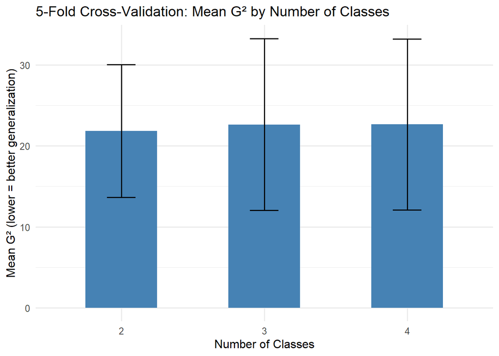

```r
ggplot(cv_kfold_df, aes(x = factor(nclass), y = mean_G2)) +
  geom_col(fill = "steelblue", width = 0.5) +
  geom_errorbar(aes(ymin = mean_G2 - sd_G2, ymax = mean_G2 + sd_G2),
                width = 0.2) +
  labs(title   = "5-Fold Cross-Validation: Mean G² by Number of Classes",
       x       = "Number of Classes",
       y       = "Mean G² (lower = better generalization)") +
  theme_minimal(base_size = 12)
```

# 5 Qualitative vs. Quantitative Differences Between Classes

Because LCA uses a categorical latent variable, its foundational assumption is that individuals differ **qualitatively** across classes rather than continuously along a dimension (as in factor analysis). In practice, empirical class solutions often contain a mixture of both.

**Quantitative differences** — classes that can be meaningfully ordered along a single underlying dimension (e.g., severity, frequency). Example: “Non-/Mild Delinquents,” “Moderate Delinquents,” “General Delinquents” represent increasing involvement in delinquency.

**Qualitative differences** — classes that cannot be readily ordered because they represent distinct *types* or *domains*. Example: “Shoplifters” and “Verbal Antagonists” differ in the type of delinquent behavior, not merely the degree.

In Multiple-Group LCA, this distinction reappears at the group level:

- If measurement invariance holds, any group differences are purely **quantitative** (differences in class prevalences, not in class definitions).
- If measurement invariance fails, the groups differ **qualitatively**: the latent classes represent fundamentally different phenomena across populations.

# 6 Missing Data

## 6.1 Missing Data Mechanisms

| Mechanism | Description | Handleable? |
| --- | --- | --- |
| MCAR (Missing Completely at Random) | Missingness unrelated to any variable | Yes |
| MAR (Missing at Random) | Missingness related to observed variables | Yes |
| MNAR (Missing Not at Random) | Missingness related to unobserved variables | No — leads to bias |

## 6.2 Methods

### 6.2.1 Full-Information Maximum Likelihood (FIML)

FIML analyzes individuals with complete and incomplete data jointly by maximizing the likelihood based on all available information. It is the default in most LCA software (e.g., Mplus). FIML handles missing data on indicator variables but **cannot handle missing data on covariates** — cases with missing covariates are dropped entirely.

### 6.2.2 Multiple Imputation (MI)

MI replaces missing values with multiple sets of plausible imputed values, creating $m$ complete datasets. The LCA is run within each imputed dataset and results are combined. MI can handle missing covariates and auxiliary variables. The main limitation is computational burden: different datasets may yield slightly different optimal class solutions, complicating pooling.

## 6.3 Strategies for Missing Covariate Data

Because FIML drops cases with missing covariates, the baseline model (indicators only) and the covariate model are fit to different samples. To prevent inconsistency:

1. **Listwise deletion prior to analysis**: Remove cases with any missing covariate data before fitting the baseline model. Simple, but reduces sample size and can introduce bias if data are MAR.
2. **Prior multiple imputation**: Impute before analysis to preserve the full sample. Ensure all covariates and their interactions are present in the imputation model.

When using the three-step approach specifically, listwise deletion is sometimes the only option because the three-step procedure requires a consistent sample across all steps.

```r
# ─── Illustration: FIML vs. listwise deletion on indicator variables ──────────

# Introduce random missing data (MAR) into indicators
sim_miss <- sim_data
for (j in paste0("Y", 1:4)) {
  miss_idx <- sample(seq_len(n), size = round(0.10 * n))  # 10% missing
  sim_miss[miss_idx, j] <- NA
}

cat("Missing data counts per indicator:\n")
```

```
## Missing data counts per indicator:
```

```r
print(colSums(is.na(sim_miss[, paste0("Y", 1:4)])))
```

```
## Y1 Y2 Y3 Y4
## 60 60 60 60
```

```r
# poLCA handles missing indicators via FIML internally (listwise on full rows
# is the default when no missing code is set; use PROC LCA / Mplus for true FIML)
# Here we demonstrate the difference in sample size

n_complete <- sum(complete.cases(sim_miss[, paste0("Y", 1:4)]))
cat("\nComplete cases (listwise deletion on indicators):", n_complete, "\n")
```

```
##
## Complete cases (listwise deletion on indicators): 396
```

```r
cat("Cases lost:", n - n_complete, "\n")
```

```
## Cases lost: 204
```

```r
# Run model on complete cases only (listwise approach)
f_miss <- cbind(Y1, Y2, Y3, Y4) ~ 1
lca_listwise <- poLCA(f_miss,
                      data   = sim_miss[complete.cases(sim_miss[, paste0("Y", 1:4)]), ],
                      nclass = 3,
                      nrep   = 10, maxiter = 1000, verbose = FALSE)

cat("\nBIC (listwise):", round(lca_listwise$bic, 2), "\n")
```

```
##
## BIC (listwise): 2133.87
```

```r
cat("BIC (full data):", round(lca_3class$bic, 2), "\n")
```

```
## BIC (full data): 3181.59
```

```r
# ─── For Mplus users (via MplusAutomation) ───────────────────────────────────
# Missing values should be recoded to a value outside the valid range (e.g., -999)
# before the analysis file is created.

# library(MplusAutomation)
# sim_miss_coded <- sim_miss
# for (j in paste0("Y", 1:4)) {
#   sim_miss_coded[is.na(sim_miss_coded[[j]]), j] <- -999
# }
# prepareMplusData(sim_miss_coded, "lca_missing.dat")
# Mplus syntax: MISSING ARE ALL (-999);
```

# 7 The Master / Nonmaster Class Framework

In skill assessment and diagnostic contexts, item-response probabilities map directly onto interpretable performance classes:

| Class | Defining Pattern |
| --- | --- |
| **Master** | High probability of passing all tasks (e.g., $\rho \approx 0.90$) |
| **Nonmaster** | High probability of failing all tasks (e.g., $\rho \approx 0.10$) |
| **Intermediate Performers** | Mixed profile — passes easy tasks, fails difficult ones |

Because LCA is probabilistic rather than deterministic, assignment to Master or Nonmaster is not guaranteed:

- **Type A error**: probability that a Master fails a task despite latent class membership
- **Type B error**: probability that a Nonmaster passes a task

Researchers assign class labels by interpreting the conditional item-response probability profiles — the software outputs probabilities, not labels.

```r
# ─── Classify a 2-class model into Master / Nonmaster ────────────────────────
lca_2class <- poLCA(f, data = sim_data[, c("Y1","Y2","Y3","Y4")],
                    nclass = 2, nrep = 10, maxiter = 1000, verbose = FALSE)

# Extract item-response probabilities (P(Y_j = 2 | Class c))
class_probs <- sapply(lca_2class$probs, function(x) x[, 2])
colnames(class_probs) <- paste0("Y", 1:4)
rownames(class_probs) <- paste0("Class ", 1:2)

cat("Item-Response Probabilities (P[response = 1 | class]):\n")
```

```
## Item-Response Probabilities (P[response = 1 | class]):
```

```r
print(round(class_probs, 3))
```

```
##            Y1    Y2    Y3    Y4
## Class 1 0.278 0.243 0.232 0.253
## Class 2 0.813 0.803 0.741 0.717
```

```r
# Label classes based on mean probability
mean_by_class <- rowMeans(class_probs)
cat("\nMean probability by class:\n")
```

```
##
## Mean probability by class:
```

```r
print(round(mean_by_class, 3))
```

```
## Class 1 Class 2
##   0.251   0.768
```

```r
labels <- ifelse(mean_by_class == max(mean_by_class), "Master", "Nonmaster")
cat("\nAssigned labels:", labels, "\n")
```

```
##
## Assigned labels: Nonmaster Master
```

# 8 Summary: Validation Checklist

| Step | Method | R Tool |
| --- | --- | --- |
| 1. Fit models for $K = 1, \ldots, K_{max}$ | Compare BIC, AIC, BLRT | `poLCA`, `tidyLPA` |
| 2. Check class separation | Entropy, modal assignment accuracy | `poLCA$posterior` |
| 3. **Construct validity** | Associate classes with covariates via 3-step approach | `poLCA` + `nnet::multinom` |
| 4. **Cross-validation** | Simple, twofold, or k-fold | Base R (see above) |
| 5. **External validity** | Multiple-Group LCA + G² difference test | `poLCA` (groups) / Mplus |
| 6. Missing data | FIML (indicators); MI (covariates) | `mice` + `poLCA` / Mplus |
| 7. Label and interpret classes | Inspect item-response probability profiles | `poLCA$probs` |

# 9 Post-Output Report

**1. Sources used:** NotebookLM Q&A export drawing from Collins & Lanza (2010) *Latent Class and Latent Transition Analysis*; Weller et al. (2020) *Latent Class Analysis: A Guide to Best Practice*; Bonikowski (2021) *Mapping Culture with Latent Class Analysis*; Eshima (2022) *An Introduction to Latent Class Analysis: Methods and Applications*.

**2. Confidence Level:** High for conceptual content (directly derived from the source material). Moderate-to-high for the R code: `poLCA` does not natively support constrained multi-group LCA or the formal three-step approach; the code demonstrates the logic and is accurate as implemented, but a production analysis should use Mplus or the `MplusAutomation` interface for the full bias-corrected three-step procedure and constrained multi-group invariance testing.

**3. Clarification Needs:** - The actual data structure of the user’s research project is not known. Code examples use simulated data and will need to be adapted to the real dataset (variable names, number of classes, number of indicators, covariate names). - The three-step approach is only approximated here via `poLCA` + `nnet`. The bias-corrected BCH or Vermunt (2010) correction requires Mplus or a specialized R implementation. If the user needs the full corrected procedure in R, clarify whether `MplusAutomation` is available.